# Plotting Tools

Statistical Computing, 36-350

Wednesday July 10, 2019

# Last time: Data frames and `apply`

- Data frames are a representation of the “classic” data table in R: rows are observations/cases, columns are variables/features
- Each column can be a different data type (but must be the same length)
- `subset()`: function for extracting rows of a data frame meeting a condition
- `split()`: function for splitting up rows of a data frame, according to a factor variable
- `apply()`: function for applying a given routine to rows or columns of a matrix or data frame
- `lapply()`: similar, but used for applying a routine to elements of a vector or list
- `sapply()`: similar, but will try to simplify the return type, in comparison to `lapply()`
- `tapply()`: function for applying a given routine to groups of elements in a vector or list, according to a factor variable

# Part I

*Plot basics: ggplot*

# Plotting in R

There’s 2 major styles of plotting in `R`. You’ve already seen examples of base `R` plots include

- `plot()`: generic plotting function
- `hist()`: histogram
- and there are many more

**But…** the `R` community has come to embrace a new approach to visualization from the `ggplot2` package.

Extremely popular graphics library

- 165,050 downloads two weeks ago

# Base graphics

- Ugly, laborious, and verbose
- There are better ways to describe statistical visualizations.

# Why ggplot2?

- Follows a common grammar, just like any language.
- It defines basic components that make up a sentence. In this case, the grammar defines components in a plot.
- moreover, treats graphics like objects, mapping properties of your dataset to attributes of the graphic.
- Supports a continuum of expertise.
- encourages iterative creation of graphics
- Get started right away but with practice you can effortless build complex, publication quality figures.

# Basics: some terminology

- `ggplot`: The main function where you specify the dataset and variables to plot
- `geoms`: geometric objects
  - `geom_point()`, `geom_bar()`, `geom_density()`, `geom_line()`, `geom_area()`
- `aes`: aesthetics
  - `shape`, transparency (`alpha`), `color`, `fill`, `linetype`.
- `scales`: Define how your data will be plotted
  - *continuous, discrete, log*

# Introduction to dataset

```r
library(gapminder)
data(gapminder)
```

|  | country | continent | year | lifeExp | pop | gdpPercap |
| --- | --- | --- | --- | --- | --- | --- |
| 1 | Afghanistan | Asia | 1952 | 28.801 | 8425333 | 779.4453145 |
| 2 | Afghanistan | Asia | 1957 | 30.332 | 9240934 | 820.8530296 |
| 3 | Afghanistan | Asia | 1962 | 31.997 | 10267083 | 853.10071 |
| 4 | Afghanistan | Asia | 1967 | 34.02 | 11537966 | 836.1971382 |
| 5 | Afghanistan | Asia | 1972 | 36.088 | 13079460 | 739.9811058 |
| 6 | Afghanistan | Asia | 1977 | 38.438 | 14880372 | 786.11336 |
| 7 | Afghanistan | Asia | 1982 | 39.854 | 12881816 | 978.0114388 |
| 8 | Afghanistan | Asia | 1987 | 40.822 | 13867957 | 852.3959448 |
| 9 | Afghanistan | Asia | 1992 | 41.674 | 16317921 | 649.3413952 |
| 10 | Afghanistan | Asia | 1997 | 41.763 | 22227415 | 635.341351 |

[output cut: 1694 more lines]

# ggplot intro: scatter plot

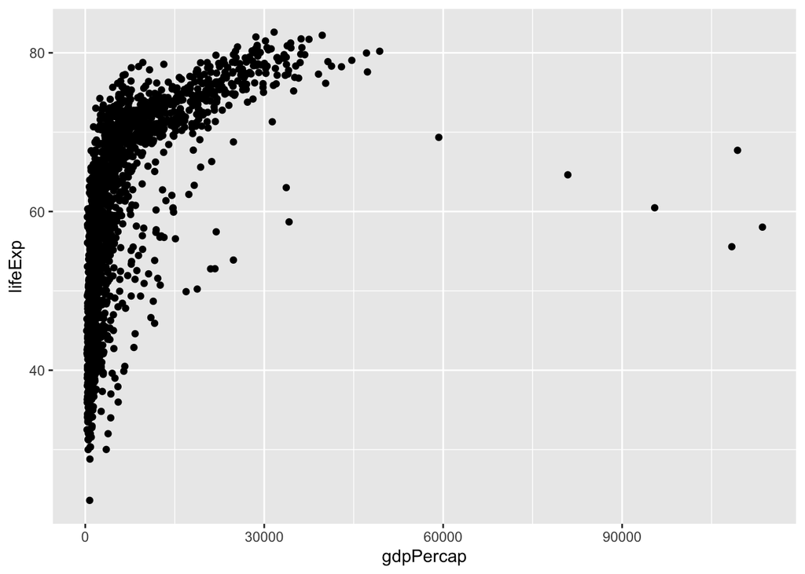

```r
library(ggplot2)
ggplot(gapminder, aes(y = lifeExp, x = gdpPercap)) +
  geom_point()
```

# ggplot intro: basic structure

```r
ggplot(data = gapminder, aes(y = lifeExp, x = gdpPercap)) +
  geom_point()
p <- ggplot(data = gapminder, aes(y = lifeExp, x = gdpPercap))
p + geom_point()
```

- specific all “global” structure in the `ggplot` function (in this case `data` and variable mappings)
- add layers of geometric objects, statistical models, and panels.

# ggplot intro: change size

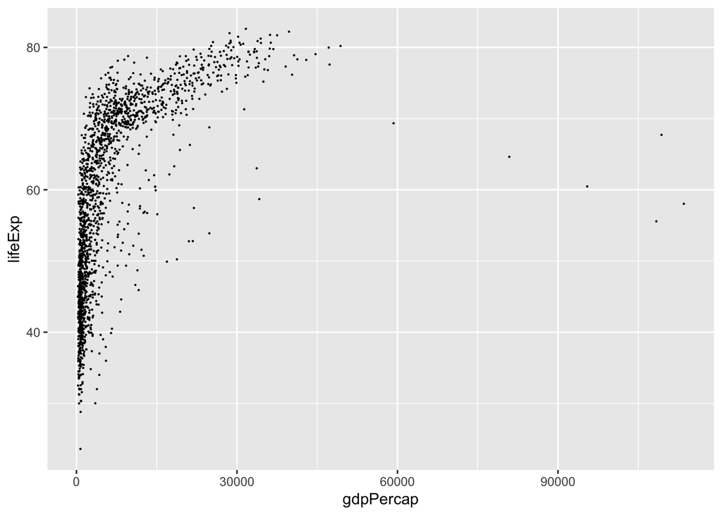

```r
ggplot(gapminder, aes(y = lifeExp, x = gdpPercap)) +
  geom_point(size = .1)
```

# ggplot intro: add color

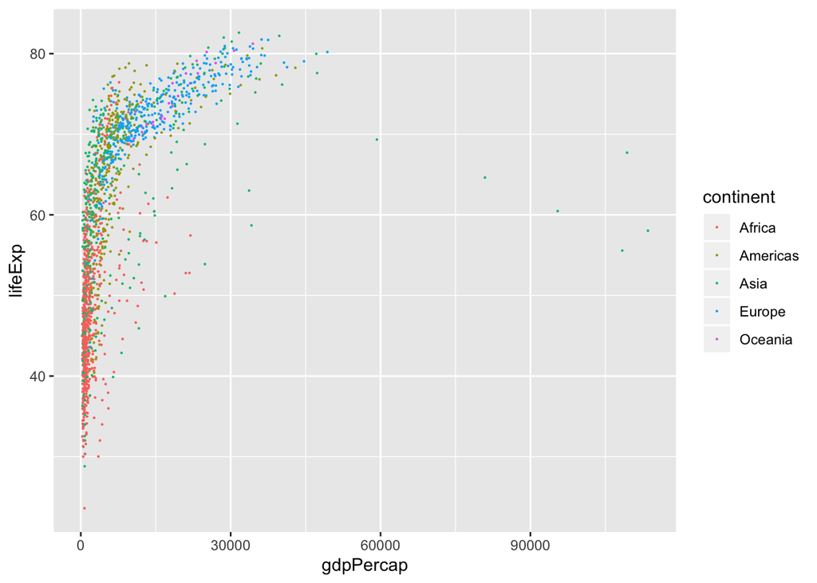

```r
ggplot(gapminder, aes(y = lifeExp, x = gdpPercap, color = continent)) +
  geom_point(size = .1)
```

# ggplot intro: change scales

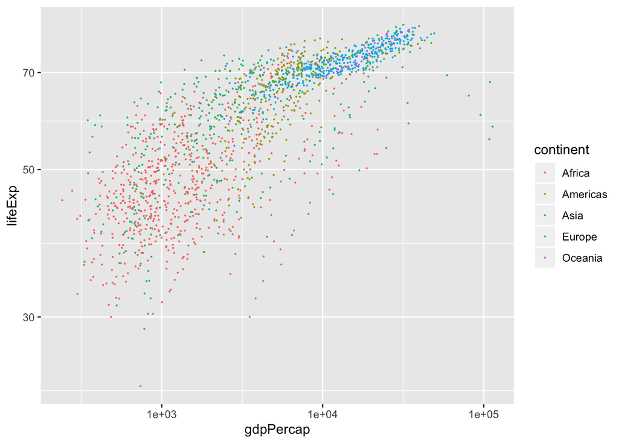

```r
ggplot(gapminder, aes(y = lifeExp, x = gdpPercap, color = continent)) +
  geom_point(size = .1) +
  scale_x_log10() + scale_y_log10()
```

# `ggplot` components review:

`ggplot2` specifications in `R` (so far):

- `data`
- `aes`: aesthetic attributes (position, length, color, symbol…)
- `geom`: geometric element (point, line, bar…)
- `scale`: scale transformation (axis limits, log scale,  
  color mapping…)

# Part II

*Examples*

# `ggplot`: boxplot

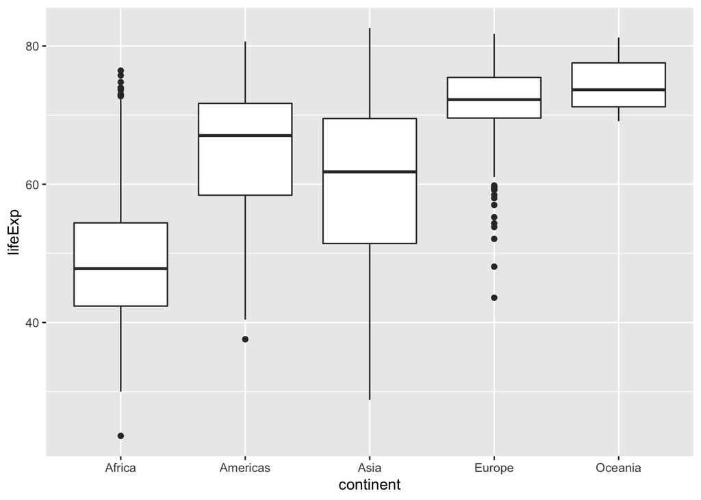

```r
ggplot(gapminder, aes(y = lifeExp, x = continent)) +
  geom_boxplot()
```

# `ggplot`: histogram (`color` vs `fill`)

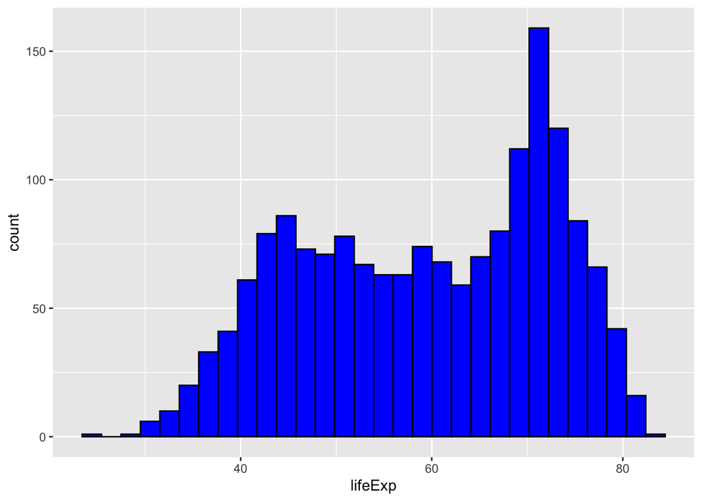

```r
ggplot(gapminder, aes(x = lifeExp)) +
  geom_histogram(color = "black", fill = "blue")
```

# `ggplot`: histogram (`fill` wrong way)

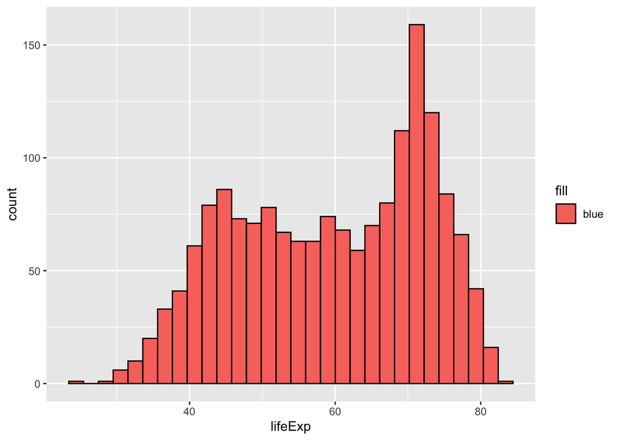

```r
ggplot(gapminder, aes(x = lifeExp)) +
  geom_histogram(aes(fill = "blue"), color = "black")
```

# `ggplot`: histogram (`fill` mapping)

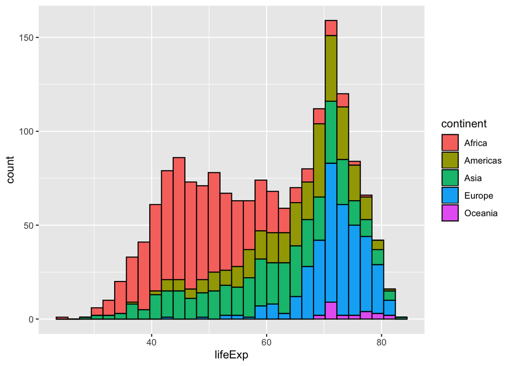

```r
ggplot(gapminder, aes(x = lifeExp)) +
  geom_histogram(aes(fill = continent), color = "black")
```

# `ggplot`: line plots

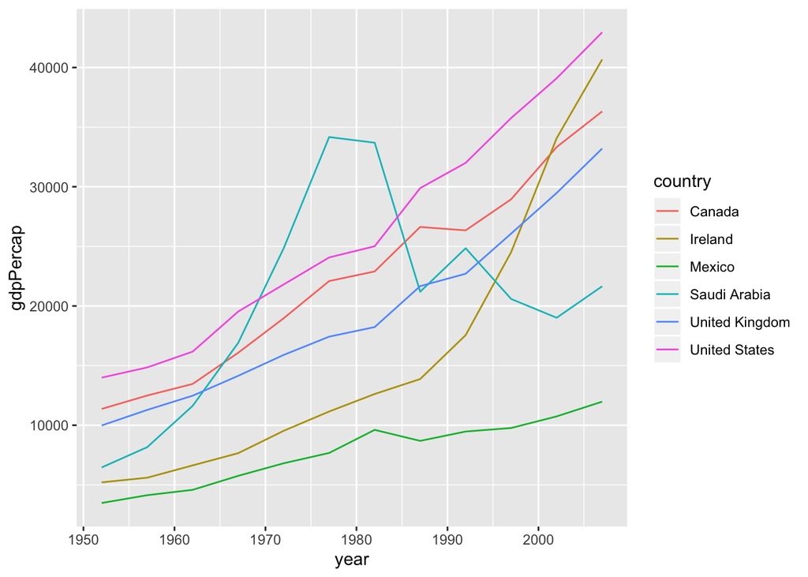

```r
ggplot(gapminder[gapminder$country %in% c("United States", "Canada",
                                          "Mexico", "United Kingdom",
                                          "Ireland",
                                          "Saudi Arabia"),],
       aes(x = year, y = gdpPercap)) +
  geom_line(aes(color = country))
```

# Discrete/Categorical Data visualizations

```r
library(tidyverse)
#  Load the data into R
titanic <- read_csv("https://raw.githubusercontent.com/benjaminleroy/stat315summer_data/master/assignments/assignment03/titanic.csv") %>%
  mutate(Pclass = factor(Pclass))
```

|  | PassengerId | Survived | Pclass | Name | Sex | Age | SibSp | Parch | Ticket | Fare | Cabin | Embarked |
| --- | --- | --- | --- | --- | --- | --- | --- | --- | --- | --- | --- | --- |
| 1 | 1 | 0 | 3 | Braund, Mr. Owen Harris | male | 22 | 1 | 0 | A/5 21171 | 7.25 |  | S |
| 2 | 2 | 1 | 1 | Cumings, Mrs. John Bradley (Florence Briggs Thayer) | female | 38 | 1 | 0 | PC 17599 | 71.2833 | C85 | C |
| 3 | 3 | 1 | 3 | Heikkinen, Miss. Laina | female | 26 | 0 | 0 | STON/O2. 3101282 | 7.925 |  | S |
| 4 | 4 | 1 | 1 | Futrelle, Mrs. Jacques Heath (Lily May Peel) | female | 35 | 1 | 0 | 113803 | 53.1 | C123 | S |
| 5 | 5 | 0 | 3 | Allen, Mr. William Henry | male | 35 | 0 | 0 | 373450 | 8.05 |  | S |
| 6 | 6 | 0 | 3 | Moran, Mr. James | male |  | 0 | 0 | 330877 | 8.4583 |  | Q |
| 7 | 7 | 0 | 1 | McCarthy, Mr. Timothy J | male | 54 | 0 | 0 | 17463 | 51.8625 | E46 | S |
| 8 | 8 | 0 | 3 | Palsson, Master. Gosta Leonard | male | 2 | 3 | 1 | 349909 | 21.075 |  | S |
| 9 | 9 | 1 | 3 | Johnson, Mrs. Oscar W (Elisabeth Vilhelmina Berg) | female | 27 | 0 | 2 | 347742 | 11.1333 |  | S |
| 10 | 10 | 1 | 2 | Nasser, Mrs. Nicholas (Adele Achem) | female | 14 | 1 | 0 | 237736 | 30.0708 |  | C |

[output cut: 881 more lines]

# ggplot intro: barchart

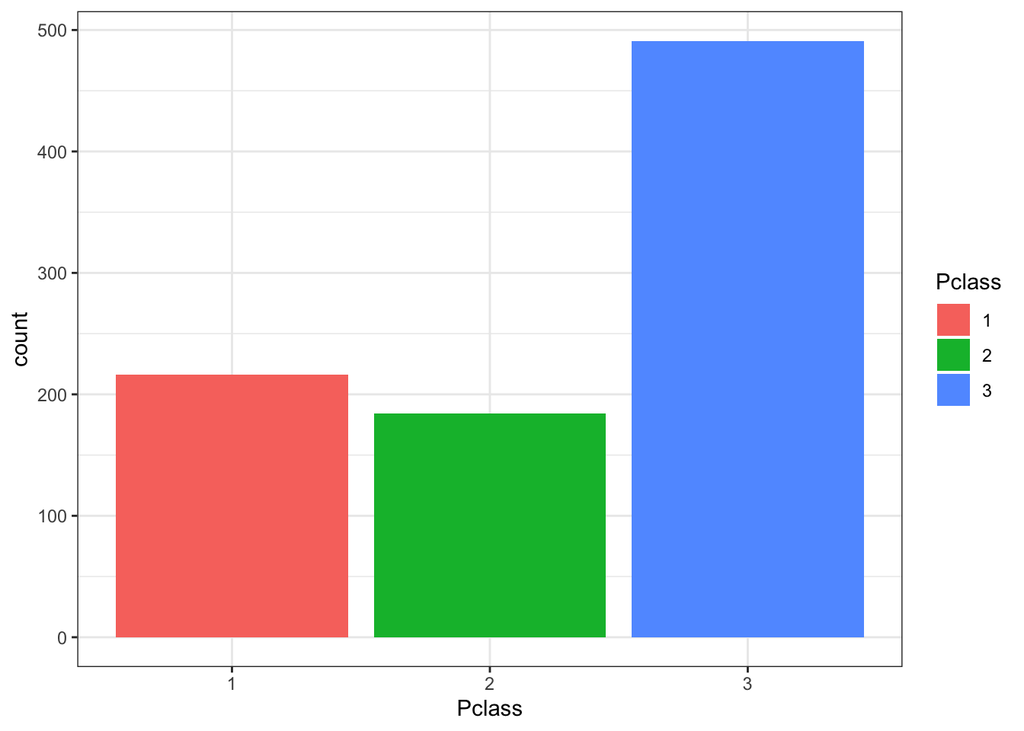

```r
ggplot(data = titanic, aes(fill = Pclass)) +
  geom_bar(aes(x = Pclass))
```

- fThis plot is using `+ coord_cartesian()` - i.e. it’s in the standard cartersian coordinate system.

# ggplot intro: spine chart

“Spine chart” (or stacked bar):  
same as bar, but with constant x-values

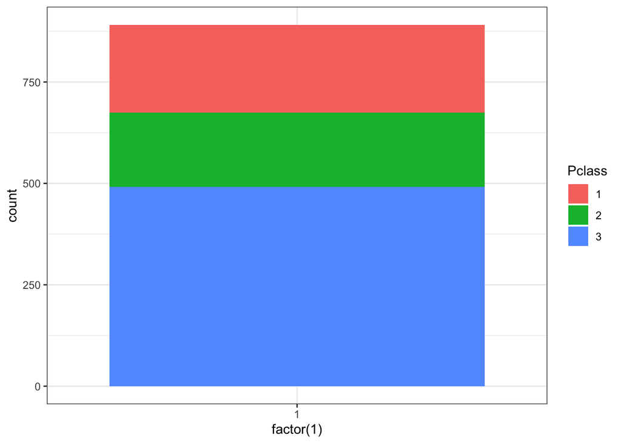

```r
ggplot(data = titanic, aes(fill = Pclass)) +
  geom_bar(aes(x = factor(1))) + coord_cartesian()
```

# ggplot intro: pie chart

“Pie chart”: spine chart, but using polar coordinates  
(angle vs. radius), with counts mapped to angle instead of height

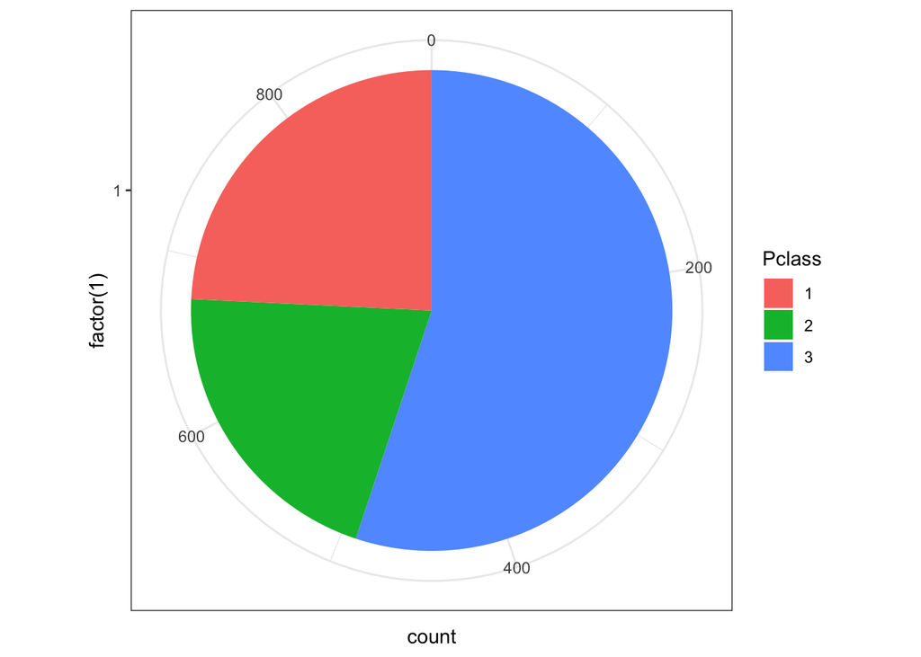

```r
ggplot(data = titanic, aes(fill = Pclass)) +
  geom_bar(aes(x = factor(1)), width = 1) + coord_polar(theta = "y")
```

# Part III

*Commentary ++*

# Grammar of Graphics: why bother

Some of these are bad ideas!—but we’ve seen the flexibility of expressing a graph from the ground up using a grammar, instead of a “chart zoo” approach (like Excel’s chart wizard)

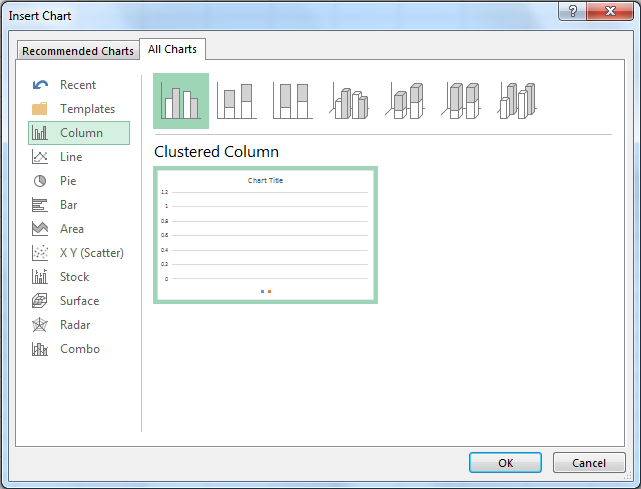

“[The grammar] makes it easier for you to iteratively update a plot, changing a single feature at a time. The grammar is also useful because it suggests the high-level aspects of a plot that *can* be changed, giving you a framework to think about graphics, and hopefully shortening the distance from mind to paper. It also encourages the use of graphics customised to a particular problem, rather than relying on generic named graphics.”  
–Hadley Wickham, [`ggplot2`](http://amzn.to/1O1rBeM)

# Speed of Use: Facets

Facets are helpful: divide into sub-plots by values of a variable,  
with automatically consistent scales and a common legend

[figure not shown]

```r
p <- ggplot(titanic, aes(x = Pclass, fill = factor(Survived))) +
  geom_bar()
p + coord_cartesian() +
  facet_wrap(~ Sex)
```

# `ggplot` components

`ggplot2` specifications in `R`:

- `data`
- `aes`: aesthetic attributes (position, length, color, symbol…)
- `stat`: statistical variable transformation (identity, count, smooth, quantile…)
- `geom`: geometric element (point, line, bar…)
- `scale`: scale transformation (axis limits, log scale,  
  color mapping…)
- `coord`: Cartesian, polar, map projection…
- `facet`: divide into subplots / small multiples using a  
  categorical variable

Of course we can also control guides (axes, legends, titles…)

# Grammar of Graphics: practice

What `data` map to which `aes` here? What `geom`, `scale`, `coord` are used? Any `facet`?

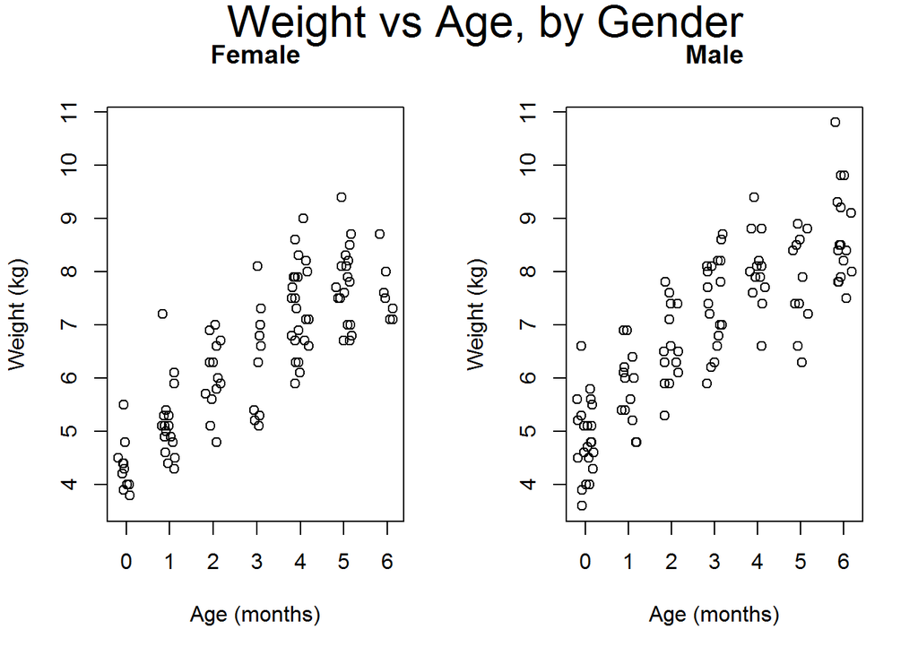

# Part III

*More Complicated Structure*

# `ggplot`: stacking and multiple images

Stacking

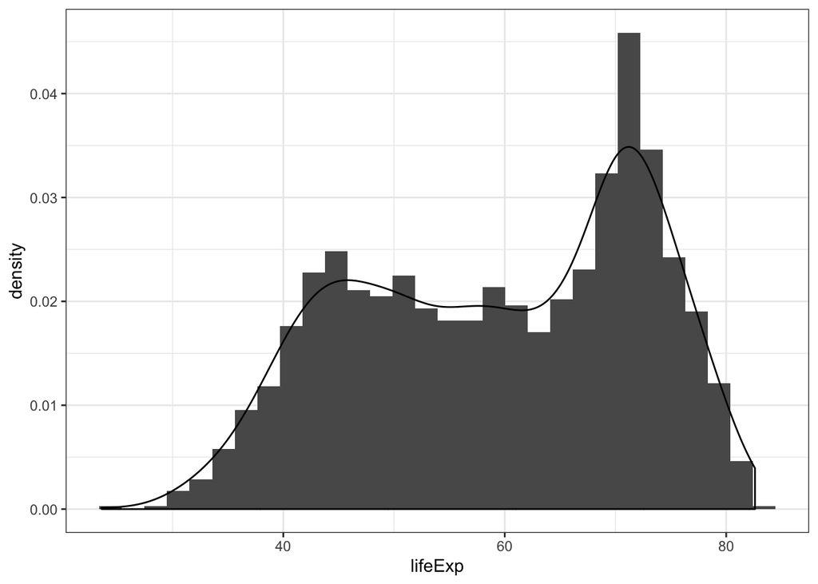

```r
a <- ggplot(gapminder,aes(x = lifeExp, y = ..density..)) +
  geom_histogram()
a + geom_density()
```

Multiple images

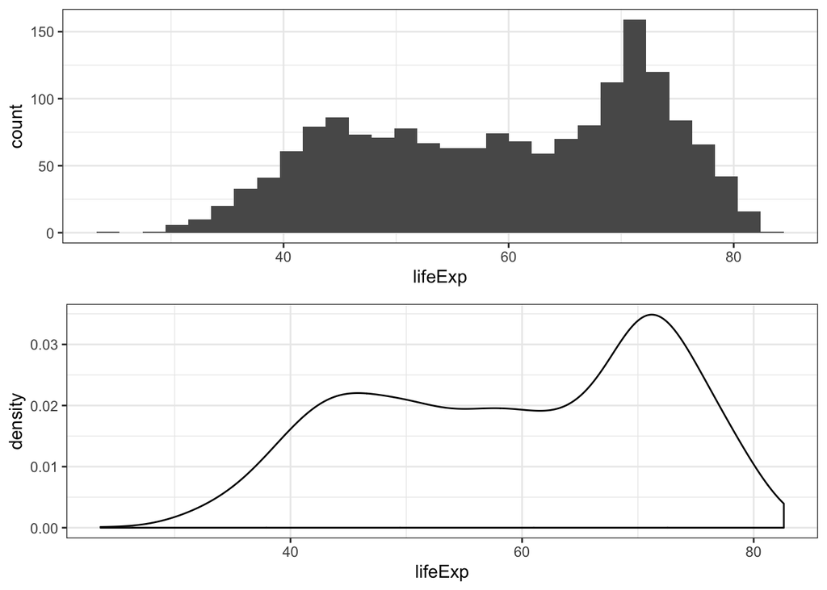

```r
library(gridExtra)
a <- ggplot(gapminder,aes(x = lifeExp)) +
  geom_histogram()
b <- ggplot(gapminder,aes(x = lifeExp)) +
  geom_density()
grid.arrange(a,b)
```

# Titles

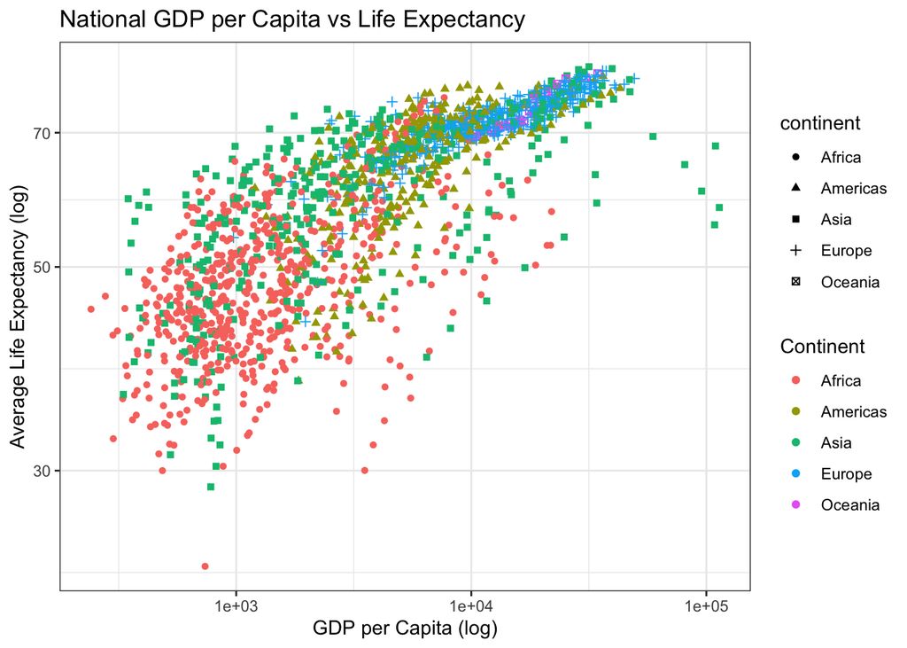

```r
ggplot(gapminder, aes(y = lifeExp, x = gdpPercap, color = continent,
                      shape = continent)) +
  geom_point() +
  scale_x_log10() + scale_y_log10() +
  labs(x = "GDP per Capita (log)",
       y = "Average Life Expectancy (log)",
       title = "National GDP per Capita vs Life Expectancy",
       color = "Continent")
```

# Part IV

*Addendum*

# Global verse local

- **Global**: data and `aes` mappings in the `ggplot()` initial call are passed to all later elements (e.g. `geom`s)
- **Local**: data and `aes` mapping in later elements (e.g. `geom`s) are only defined for that specific element

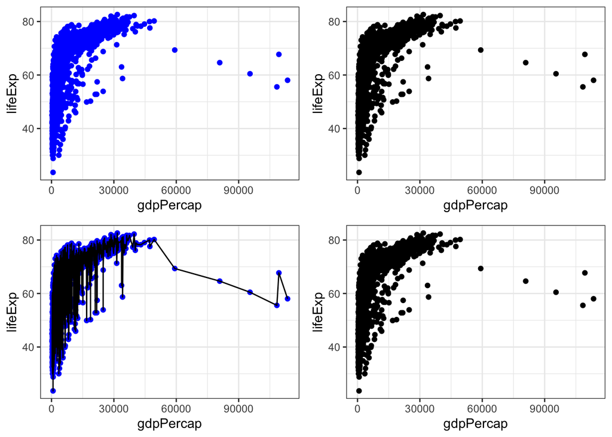

```r
g_vis <- ggplot(gapminder, aes(y = lifeExp, x = gdpPercap)) + # global
  geom_point(color = "blue")
l_vis <- ggplot() +
  geom_point(data = gapminder, aes(y = lifeExp, x = gdpPercap)) # local
# ^ notice the need to write data = gapminder
g_vis2 <- g_vis + geom_line()
l_vis2 <- l_vis + geom_line()  # geom_line doesn't do anything here

grid.arrange(g_vis, l_vis,
             g_vis2, l_vis2, nrow = 2)
```

# Multiple data sources

We can also override global mapping and data sources.

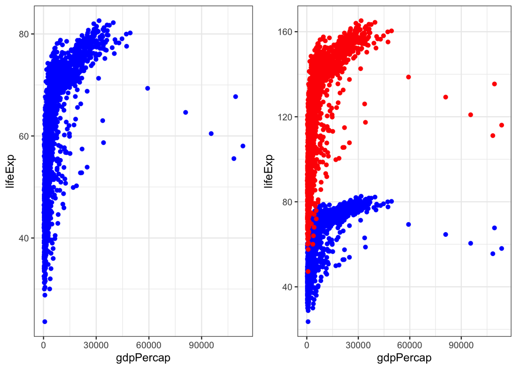

```r
gapminder2 <- gapminder
gapminder2$lifeExp <- 2 * gapminder2$lifeExp

g_vis <- ggplot(gapminder, aes(y = lifeExp, x = gdpPercap)) + # global
  geom_point(color = "blue")
g_vis_plus_another <- g_vis +
  geom_point(data = gapminder2, aes(y = lifeExp, x = gdpPercap), color = "red")

grid.arrange(g_vis, g_vis_plus_another, nrow = 1)
```

# Summary

- `ggplot` is plotting package for the future of `R` computing
- `ggplot` acts like a grammar - we are able to extend the layers iterative
- `ggplot()` defines global information for all following elements (relative to data and `aes` mappings)
- `aes` allows you to define how to make columns a data.frame to aesthetics of the graphic
- `geom_...` define geometric attributes of the graphic
- `facets` allow one to divide the graphic up conditional on a factor variable

# Summary (Code Related)

`ggplot2` specifications in `R`:

- `data`
- `aes`: aesthetic attributes (position, length, color, symbol…)
- `stat`: statistical variable transformation (identity, count, smooth, quantile…)
- `geom`: geometric element (point, line, bar…)
- `scale`: scale transformation (axis limits, log scale,  
  color mapping…)
- `coord`: Cartesian, polar, map projection…
- `facet`: divide into subplots / small multiples using a  
  categorical variable

Of course we can also control guides (axes, legends, titles…)